# Kirjeldav statistika 2

Indrek Soidla

2023-09-18

Laeme sisse tööks vajalikud paketid.

```r
library(tidyverse)
library(summarytools)
library(modeest)
library(lsr)
library(psych)
library(ggplot2)
library(haven)
library(TAM)
library(matrixStats)
```

# Jaotusparameetrid

Eelmisel korral uurisime põhiliselt, kuidas saada ülevaade uuritavatest tunnustest sagedusjaotuste ja risttabelite ehk tunnuste ühisjaotuste abil. Neid on mõttekas kasutada eelkõige kategoriaalsete tunnuste ehk nominaal- ja järjestustunnuste puhul (kui järjestustunnuses pole liiga palju kategooriaid), sest arvuliste tunnuste puhul oleks erinevaid väärtusi ja nende kohta arvutatavaid sagedusi lihtsalt liiga palju, et ülevaatlikku pilti tunnusest saada. Arvuliste tunnuste puhul saame esmase ülevaate tunnuse jaotusest kokkuvõtlike näitajate abil, mida nimetatakse ka jaotusparameetriteks. Mõnda neist oleme põgusalt ka mingites näidetes juba kasutanud, nt aritmeetilist keskmist, miinimumi ja maksimumi. Vaatame seekord erinevaid selliseid näitajaid lähemalt, mida nad endast kujutavad, millistel puhkudel neid on mõttekas kasutada ja kuidas neid tõlgendada.

Võtame jaotusparameetrite näidete aluseks andmestiku, kus on andmed aastatel 1999-2018 USA föderaalteenistujatele tehtud kingituste kohta, andmed on seal umbes 8000 kingituse kohta. Huvitav on see, et seaduse järgi ei tohiks selliseid kingitusi üldse vastu võtta, aga leidub erandeid, eriti välisriikide esindajate visiitidega seoses, kui kingituse tagasilükkamine võib tekitada solvumist või piinlikkust. Taolised erandid tuleb registris alati fikseerida (mis selliste kingitustega võib juhtuda, kirjeldatakse Eesti kontekstis humoorikalt [siin](http://kontoris.blogspot.com/2019/01/kuidas-kaitutakse-eetiliselt.html)).

Laeme andmed sisse. Andmed on csv-formaadis, antud juhul on failis üksikväärtused eraldatud komadega, seetõttu kasutame andmete sisselaadimiseks funktsiooni `read.csv` (mitte `read.csv2`). Kas csv-failis on väärtused eraldatud komadega või semikoolonitega, on kõige lihtsam teada saada, avades faili lihtsas tekstiredaktoris nagu Notepad või Notepad++ (kui fail just ülemäära suur ei ole, nt kümnetes megabaitides). Lühikese ülevaate andmestikus olevatest andmetest (tunnuste tüübid ja esimestel ridadel olevad väärtused) saate funktsiooniga `str`.

```r
gifts <- read.csv("data/gifts.csv")
str(gifts)
```

```
## 'data.frame':    8392 obs. of  12 variables:
##  $ X               : int  1 2 3 4 5 6 7 8 9 10 ...
##  $ id              : int  1 2 3 4 5 6 7 8 9 10 ...
##  $ recipient       : chr  "President" "President" "President" "President" ...
##  $ agency_name     : chr  NA NA NA NA ...
##  $ year_received   : int  1999 1999 1999 1999 1999 1999 1999 1999 1999 1999 ...
##  $ date_received   : chr  NA NA NA NA ...
##  $ donor           : chr  "His Excellency Petru Lucinschi, President of the Republic of Moldova" "His Excellency, Keizo Obuchi, The Prime Minister of Japan and Mrs. Obuchi" "Sr. Victor Cervera Pacheco, Governor of Yucatan Mexico" "His Holiness John Paul II" ...
##  $ donor_country   : chr  "Moldova" "Japan" "Mexico" NA ...
##  $ gift_description: chr  "40\" x 29\" gilt framed oil painting of an autumn landscape that depicts a shepherd and goats. Recd--October 20"| __truncated__ "Six bottles of sake. Recd--November 20, 1998. Est. Value--$72. Accepted by Another Government Agency. Two bonsa"| __truncated__ "49\" tall wo…
##  $ value_usd       : num  1500 14500 1000 1015 660 ...
##  $ justification   : chr  "Non-acceptance would cause embarrassment to donor and U.S. Government" "Non-acceptance would cause embarrassment to donor and U.S. Government" "Non-acceptance would cause embarrassment to donor and U.S. Government" "Non-acceptance would cause embarrassment to donor and …
##  $ region          : chr  "Europe" "Asia" "Americas" NA ...
```

## Keskväärtust kirjeldavad näitajad

Soovime näiteks teada, kas erinevate riikide esindajad on teinud teistest kallimaid/odavamaid kingitusi. Erinevaid riike on palju, seetõttu võtame lihtsama näite jaoks tunnuse, kus on vähem kategooriaid, ehk uurime, kas eri maailmajagudest pärit külalised priiskavad kingitustega rohkem kui teised. Kõigi umbes 8000 kingituse väärtuste võrdlemine on keeruline, seega on mõttekas arvutada mingi kokkuvõtlik näitaja, nt mingi näitaja, mis näitaks kingituse keskmist või tüüpilist väärtust maailmajaos, nt keskmine.

### Aritmeetiline keskmine

Kui räägitakse tunnuse või mingite väärtuste keskmisest, siis enamasti mõeldakse selle all aritmeetilist keskmist: väärtuste summat jagatud väärtuste arvuga. Arvutame aritmeetilised keskmised regiooniti, kasutades selleks paketi `dplyr` võimalusi ja funktsiooni `mean`. Lisame ka kingituste arvu igas regioonis (indiviidide ehk ridade arv) funktsiooniga `n`.

```r
gifts %>%
  group_by(region) %>%
  summarise(keskmine = mean(value_usd, na.rm = TRUE),
            arv = n()) %>%
  arrange(desc(keskmine))
```

```
## # A tibble: 6 × 3
##   region   keskmine   arv
##   <chr>       <dbl> <int>
## 1 Asia        3580.  4233
## 2 Africa      1963.   715
## 3 <NA>        1490.  1417
## 4 Europe      1294.  1361
## 5 Oceania     1141.   125
## 6 Americas     864.   541
```

Teiste seas esitatakse kingituste keskmine rahaline väärtus ja arv ka selliste kingituste kohta, mille puhul riiki (selle põhjal on tuletatud regioon) polnud märgitud, nende puhul võis kinkija näol olla tegu nt rahvusvahelise organisatsiooni esindajaga või peeti vajalikuks kinkija isik salastada või ei esindanud kinkija otseselt oma riiki vms. Arvutatud näitajate põhjal võiks järeldada, et kaugelt kõige kallimaid kingitusi on toonud Aasia riikide esindajad, Euroopa riikide esindajad on olnud kingituste rahalise väärtuse poolest keskmiselt tagasihoidlikumad, aga mitte kõige tagasihoidlikumad.

Tihti tõlgendatakse aritmeetilist keskmist kui arvväärtuste kogumi keskmist või tüüpilist väärtust. Samas on hea meeles pidada, et täpselt aritmeetilise keskmise väärtust ei pruugi kogumis üldse esinedagi, ka ei pruugi aritmeetiline keskmine näidata tüüpilist väärtust, seda juhul, kui tunnuse jaotus pole sümmeetriline ja/või esineb erindeid ehk teistest tugevalt eristuvaid väärtuseid. Skaala kummagi otsa erandlikumaid väärtuseid näeme nt funktsioonidega `min` ja `max`.

```r
gifts %>%
  group_by(region) %>%
  summarise(keskmine = mean(value_usd, na.rm = TRUE),
            min = min(value_usd, na.rm = TRUE),
            max = max(value_usd, na.rm = TRUE),
            arv = n()) %>%
  arrange(desc(keskmine))
```

```
## # A tibble: 6 × 5
##   region   keskmine   min      max   arv
##   <chr>       <dbl> <dbl>    <dbl> <int>
## 1 Asia        3580.  1.32 1000000   4233
## 2 Africa      1963. 30     212225    715
## 3 <NA>        1490.  6      23760.  1417
## 4 Europe      1294.  1     124000   1361
## 5 Oceania     1141. 15      17031    125
## 6 Americas     864.  3.54   40000    541
```

Näeme, et keskmised on kõigi regioonide puhul mitte miinimumi ja maksimumi vahelise skaala keskel, vaid väga palju lähemal miinimumile. See näitab, et väga kalleid kingitusi on ilmselt vähe või esineb üksikuid väga kalleid kingitusi. Sellised ekstreemsed väärtused või jaotuse tugev asümmeetrilisus tõstavad aritmeetilise keskmise väärtust, mistõttu ei näita antud juhul aritmeetilised keskmised kuigi hästi n-ö tüüpilise kingituse rahalist väärtust. Seetõttu ei pruugi ka aritmeetiline keskmine olla tunnuse jaotuse (või keskmise väärtuse või tüüpilise väärtuse) kirjeldamiseks kõige adekvaatsem lahendus, sel juhul võib tunnuse jaotusest parema pildi anda mediaan.

### Mediaan

Lihtsalt öeldes saame mediaani, kui asetame kõik tunnuse väärtused suuruse järjekorras ritta ehk tekitame variatsioonirea ja leiame selle variatsioonirea keskmise elemendi väärtuse. Seega sisulises mõttes näitab mediaan n-ö keskmist indiviidi paremini kui aritmeetiline keskmine, kuigi praktikas kiputakse ekslikult nii tõlgendama hoopis aritmeetilist keskmist.

```r
gifts %>%
  group_by(region) %>%
  summarise(keskmine = mean(value_usd, na.rm = TRUE),
            mediaan = median(value_usd, na.rm = TRUE),
            min = min(value_usd, na.rm = TRUE),
            max = max(value_usd, na.rm = TRUE),
            arv = n()) %>%
  arrange(desc(keskmine))
```

```
## # A tibble: 6 × 6
##   region   keskmine mediaan   min      max   arv
##   <chr>       <dbl>   <dbl> <dbl>    <dbl> <int>
## 1 Asia        3580.    650   1.32 1000000   4233
## 2 Africa      1963.    630  30     212225    715
## 3 <NA>        1490.    774.  6      23760.  1417
## 4 Europe      1294.    550   1     124000   1361
## 5 Oceania     1141.    513. 15      17031    125
## 6 Americas     864.    500   3.54   40000    541
```

Tõepoolest, kingituste mediaanväärtused on aritmeetilistest keskmistest märkimisväärselt väiksemad. Kui tunnuse mediaan on aritmeetilisest keskmisest märkimisväärselt erinev, vihjab see, et tunnuse jaotus ei ole sümmeetriline või esineb erindeid, mistõttu olekski tunnuse jaotuse kirjeldamiseks sobivam mediaan. Vale pole ka aritmeetiline keskmine, ainult et nagu näha eelnevast näitest, tema tõlgendamisel võib teha eksijäreldusi. Kui mediaan ja aritmeetiline keskmine langevad kokku, pole vahet, kumba kasutada.

Olgu siinkohal ka välja toodud, et kõiki käsus `summarise` olevaid jaotusparameetrite funktsioone saab kasutada ka kogu tunnuse kohta jaotusparameetrite arvutamiseks (mitte ainult grupiti):

```r
mean(gifts$value_usd, na.rm = TRUE)
```

```
## [1] 2520.665
```

```r
median(gifts$value_usd, na.rm = TRUE)
```

```
## [1] 645.5
```

### Mood

Vahel kasutatakse jaotuse kirjeldamiseks ka moodi, mis on jaotuses kõige enam esinev väärtus. Moodi arvutamiseks pole R-i põhipaketis omaette funktsiooni (funktsioon `mode` on, aga näitab hoopis midagi muud), moodi arvutamiseks peame kasutama funktsiooni `mlv` paketist `modeest`.

```r
gifts %>%
  group_by(region) %>%
  summarise(keskmine = mean(value_usd, na.rm = TRUE),
            mediaan = median(value_usd, na.rm = TRUE),
            mood = mfv(value_usd, na_rm = TRUE), # miskipärast on funktsiooni mfv loojad otsustanud nimetada teise argumendi `na_rm`, mitte `na.rm`
            min = min(value_usd, na.rm = TRUE),
            max = max(value_usd, na.rm = TRUE),
            arv = n()) %>%
  arrange(desc(keskmine))
```

```
## # A tibble: 6 × 7
##   region   keskmine mediaan  mood   min      max   arv
##   <chr>       <dbl>   <dbl> <dbl> <dbl>    <dbl> <int>
## 1 Asia        3580.    650    500  1.32 1000000   4233
## 2 Africa      1963.    630    450 30     212225    715
## 3 <NA>        1490.    774.   500  6      23760.  1417
## 4 Europe      1294.    550    500  1     124000   1361
## 5 Oceania     1141.    513.  1000 15      17031    125
## 6 Americas     864.    500    500  3.54   40000    541
```

Mood ei ole tunnuse jaotuse kirjeldamisel niivõrd kasulik kui mediaan või aritmeetiline keskmine, sest ei ütle midagi selle kohta, kui palju seda kõige rohkem esinevat väärtust esineb (nt pideva tunnuse puhul, kus on murdarvud, võib tuhatkonnast väärtusest olla kõige enam esineva väärtusega indiviide pelgalt mõni üksik). Ka võib mõnda teist väärtust esineda pea sama palju kui moodi. Rohkem kasu võib moodist (mitte moest) olla järjestustunnuse, kus on vähe erinevaid väärtuseid, kirjeldamisel.

## Hajuvust kirjeldavad näitajad

### Dispersioon ja standardhälve

Eelnevad jaotusparameetrid võimaldasid saada kokkuvõtliku näitaja põhjal info tunnuse tüüpiliste väärtuste kohta. Samas ei ütle nad väga palju selle kohta, kui tüüpiline see näitaja tunnuses esinevate väärtuste suhtes on, st kas tunnuse väärtused on koondunud tihedalt selle jaotusparameetri ümber või pigem hajusalt üle terve skaala. Seda, tunnuse hajuvust, kirjeldavad näiteks dispersioon ja standardhälve. Tunnuse dispersioon saadakse, arvutades iga indiviidi väärtuse erinevuse ehk hälbe tunnuse keskmisest, võttes saadud hälbed ruutu ja arvutades nende ruuthälvete keskmise:

$$s^2 =
\frac{1}{n}\overset{n}{\underset{j=1}\Sigma}(x_j - m)^2$$
Antud valemis $m$ on tunnuse keskmine, $x_j$ on $j$-nda indiviidi väärtus tunnuses, $n$ on indiviidide (siin sama, mis tunnuses olevate väärtuste) arv. Kreeka $\Sigma$ tähistab summeerimist, antud juhul ruuthälvete summeerimist.

Dispersiooni väljendatakse tunnuse ruutühikutes, mida on keeruline tõlgendada, nt tunnuse value_usd dispersioon oleks ruutdollarites. Seepärast võidakse praktikas eelistada dispersiooni asemel standardhälvet, mis on ruutjuur dispersioonist:

$$s =
\sqrt{\frac{1}{n}\overset{n}{\underset{j=1}\Sigma}(x_j -
m)^2}$$

Standardhälvet ja dispersiooni tõlgendatakse vahel kui indiviidide keskmist erinevust tunnuse keskmisest ehk kui keskmist hälvet tunnuse keskmisest, kuigi päris täpne selline määratlus pole. Õige oleks öelda, et dispersioon on keskmine ruuthälve tunnuse keskmisest ehk ruuthälvete aritmeetiline keskmine, standardhälve on seega ruutjuur ruuthälvete aritmeetilisest keskmisest. Intuitiivselt on seda mõnevõrra keeruline haarata, lihtsam on mõista keskmist absoluuthälvet *(average absolute deviation*, mis ongi keskmine hälve keskmisest:

$$d =
\frac{1}{n}\overset{n}{\underset{j=1}\Sigma}|x_j - m|$$
Võrreldes keskmise absoluuthälbega on standardhälve ja eriti dispersioon rohkem mõjutatud erinditest ehk keskmisest eriti palju hälbivatest väärtustest (sest hälbed võetakse ruutu).

Kui keskmist absoluuthälvet on intuitiivselt lihtsam mõista kui nt standardhälvet, siis miks üldse kasutatakse standardhälvet (ja keskmist absoluuthälvet kasutatakse nii harva, et ma ei pannud seda isegi käesoleva alapeatüki pealkirja)? Sest standardhälve on oluline parameeter erinevate tüüpjaotuste ehk teoreetiliste jaotuste kirjeldamisel ja järeldava analüüsi puhul (st kui soovime valimi põhjal teha järeldusi populatsiooni kohta).

Arvutame kõik kolm hajuvust kirjeldavat jaotusparameetrit.

```r
gifts %>%
  group_by(region) %>%
  summarise(keskmine = mean(value_usd, na.rm = TRUE),
            disp = var(value_usd, na.rm = TRUE),
            std = sd(value_usd, na.rm = TRUE),
            aad = aad(value_usd, na.rm = TRUE),
            mediaan = median(value_usd, na.rm = TRUE),
            mood = mfv(value_usd, na_rm = TRUE), # miskipärast on funktsiooni mfv loojad otsustanud nimetada teise argumendi `na_rm`, mitte `na.rm`
            min = min(value_usd, na.rm = TRUE),
            max = max(value_usd, na.rm = TRUE),
            arv = n()) %>%
  arrange(desc(keskmine))
```

```
## # A tibble: 6 × 10
##   region   keskmine       disp    std   aad mediaan  mood   min      max   arv
##   <chr>       <dbl>      <dbl>  <dbl> <dbl>   <dbl> <dbl> <dbl>    <dbl> <int>
## 1 Asia        3580. 810496494. 28469. 4815.    650    500  1.32 1000000   4233
## 2 Africa      1963.  95563696.  9776. 2184.    630    450 30     212225    715
## 3 <NA>        1490.   4014910.  2004. 1179.    774.   500  6      23760.  1417
## 4 Europe      1294.  16767489.  4095. 1207.    550    500  1     124000   1361
## 5 Oceania     1141.   4220944.  2054. 1061.    513.  1000 15      17031    125
## 6 Americas     864.   3976021.  1994.  625.    500    500  3.54   40000    541
```

Tabelist on kohe näha, et dispersiooni näitajad on palju suuremad, nii suured, et neid on keeruline isegi täpselt välja lugeda (ruutdollarid, eksole). (Juhendis ehk html-failis raskendab lugemist veel see, et viie- ja rohkemakohalised arvud esitatakse kümne astmetega, nt $8.10e8$ tähendab $8.1 * 10^8$ ehk 810 miljonit.) Sel põhjusel praktikas ka dispersioone eriti ei kasutata, samas on siiski kvantitatiivsete meetodite alaste tekstide lugemisel kasulik teada, mida dispersioon endast kujutab. Standardhälbed ja keskmised absoluuthälbed on palju lähemal üksteisele, kuigi standardhälbed on keskmisestest absoluuthälvetest kaks kuni üsna mitu korda suuremad. Millest sellised erinevused kahes näitajas erinevate regioonide korral? Sest standardhälve on erindite suhtes tundlikum, seega ilmselt näiteks Aasia riikide esindajate kingituste hulgas leidub kinke, mis on eriti kõrge rahalise väärtusega. Euroopast tulnud kinkide puhul saame keskmise absoluuthälbe põhjal öelda, et kui kingituste väärtuste aritmeetiline keskmine on 1294 dollarit, siis keskmiselt erinevad kingitused sellest keskmisest 1207 dollari võrra.

Kuigi keskmist absoluutsethälvet võib olla lihtsam intuitiivselt mõista kui standardhälvet, pole nende näitajate konkreetsete arvväärtuste sisuline tõlgendamine lihtne ei ühe ega teise puhul. Pigem ongi nende tõlgendamine mõttekas suhtelises plaanis: Aasia kingituste kallidus varieerub rohkem kui Euroopa kingituste väärtus, variatiivsus Euroopa kingituste rahalises väärtuses on omakorda suurem kui nt Okeaaniast või Põhja- ja Lõuna-Ameerikast tulnud kingituste puhul.

### Absoluutne mediaanhälve

Kui erinditega tunnuse keskväärtuse kirjeldamisel oli võimalik aritmeetilise asemel kasutada erindite suhtes ükskõikset mediaani, siis peaks midagi taolist olema võimalik ka hajuvuse kirjeldamisel? Just nii, selleks on absoluutne mediaanhälve *(median absolute deviation)*, mis arvutatakse sarnaselt keskmisele absoluuthälbele, ainult et keskmiste asemel on mediaanid. Seega absoluutse mediaanhälbe puhul arvutatakse iga individuaalse väärtuse erinevus ehk hälve tunnuse mediaanist, ja saadud hälvete absoluutväärtustest võetakse mediaan.

```r
gifts %>%
  group_by(region) %>%
  summarise(keskmine = mean(value_usd, na.rm = TRUE),
            disp = var(value_usd, na.rm = TRUE),
            std = sd(value_usd, na.rm = TRUE),
            aad = aad(value_usd, na.rm = TRUE),
            mediaan = median(value_usd, na.rm = TRUE),
            mad = mad(value_usd, constant = 1, na.rm = TRUE),
            mood = mfv(value_usd, na_rm = TRUE), # miskipärast on funktsiooni mfv loojad otsustanud nimetada teise argumendi `na_rm`, mitte `na.rm`
            min = min(value_usd, na.rm = TRUE),
            max = max(value_usd, na.rm = TRUE),
            arv = n()) %>%
  arrange(desc(keskmine))
```

```
## # A tibble: 6 × 11
##   region   keskmine     disp    std   aad mediaan   mad  mood   min    max   arv
##   <chr>       <dbl>    <dbl>  <dbl> <dbl>   <dbl> <dbl> <dbl> <dbl>  <dbl> <int>
## 1 Asia        3580.   8.10e8 28469. 4815.    650   304.   500  1.32 1   e6  4233
## 2 Africa      1963.   9.56e7  9776. 2184.    630   280    450 30    2.12e5   715
## 3 <NA>        1490.   4.01e6  2004. 1179.    774.  391.   500  6    2.38e4  1417
## 4 Europe      1294.   1.68e7  4095. 1207.    550   250    500  1    1.24e5  1361
## 5 Oceania     1141.   4.22e6  2054. 1061.    513.  350.  1000 15    1.70e4   125
## 6 Americas     864.   3.98e6  1994.  625.    500   183.   500  3.54 4   e4   541
```

Seega saab öelda, et näiteks Euroopast tulnud kingituse tüüpiline rahaline väärtus on 550 dollarit; samas kõiki kingitusi see väärtus täpselt ei kirjelda, aga saab öelda, et tüüpiline erinevus sellest mediaanväärtusest oli 250 dollarit. Sellise tõlgenduse tagab R-s funktsiooni `mad` puhul argumendi `constant` väärtus 1; kui seda ei oleks defineeritud, korrutataks vaikeseadena MAD-i väärtused läbi 1,48-ga, mis tagab MAD-i parema võrreldavuse standardhälbega. Küll aga poleks sellisel juhul MAD nii lihtsalt tõlgendatav nagu antud näites.

### Kvantiilid ja kvartiilid

Eelnevate hajuvusparameetritega saame küll hinnata tunnuse hajuvust, kuid me ei saa siiski teada, millisesse vahemikku jäävad nt 20% või 50% tüüpilisemate indiviidide väärtused. Lisaks tunnuse jaotusest parema ülevaate saamisele võib see ka sisuliselt oluline info olla. Selle jaoks saab eelnevalt mainitud variatsioonirea alusel arvutada kvantiilid ehk jagada variatsioonirea (st indiviidide väärtused reastatuna väikseimast suurimani) teatud arvuks võrdseteks osadeks ja leida osade piire kirjeldavad tunnuse väärtused. Näiteks kui reastame meie andmestikus kingituste väärtused väikseimast suurimani ja jaotame saadud variatsioonirea viieks osaks, saame teada, millised on 20%, 40%, 60% ja 80% piiril olevate kingituste väärtused. Teisisõnu saame siis teada kvintiilide väärtused (ladina keelest *quintus* - viis), mis ütlevad meile, millisesse vahemikku jäävad nt keskmise 20% või 60% kingituste väärtused. Samamoodi saame tunnuse `value_usd` variatsioonirea jagada nelja ossa ja leida 25%, 50% ja 75% piiril olevate kingituste rahalised väärtused ehk tunnuse `value_usd` kvartiilid (ld k *quartus* - neli). 25%-kvantiili nimetatakse ka alumiseks kvartiiliks ja 75%-kvantiili ülemiseks kvartiiliks. Nende kvartiilide vahet nimetatakse kvartiilhaardeks *(interquartile range, IQR)*, tegu on arvuga, mis näitab selle lõigu pikkust, kuhu jääb keskmine 1/2 kogumist. 50%-kvantiil on sama, mis mediaan.

Samal põhimõttel saab arvutada näiteks 10%-, 20%-, 30%- jne kvantiilid ehk detsiilid (variatsioonirida jaotatakse 10 osaks), mida kasutatakse tihti näiteks sissetuleku jaotuse kirjeldamiseks.

Lisame olemasolevasse jaotusparameetrite tabelisse kvartiilid. Kuna mediaan juba tabelis on, siis lisame ainult alumise ja ülemise kvartiili. Kuna tabel on tänu andmete grupeerimisele *tibble*-formaadis, esitataks html-failis vaikeseadena ainult need veerud, mis lehe laiusesse ära mahuvad; lisame koodi lõppu ka käsu `print(width = Inf)`, millega seadistame tabeli nii, et kuvataks kõik veerud.

```r
gifts %>%
  group_by(region) %>%
  summarise(keskmine = mean(value_usd, na.rm = TRUE),
            disp = var(value_usd, na.rm = TRUE),
            std = sd(value_usd, na.rm = TRUE),
            aad = aad(value_usd, na.rm = TRUE),
            alum_kvart = quantile(value_usd, probs = 0.25, na.rm = TRUE),
            mediaan = median(value_usd, na.rm = TRUE),
            ylem_kvart = quantile(value_usd, probs = 0.75, na.rm = TRUE),
            iqr = IQR(value_usd, na.rm = TRUE),
            mad = mad(value_usd, constant = 1, na.rm = TRUE),
            mood = mfv(value_usd, na_rm = TRUE), # miskipärast on funktsiooni mfv loojad otsustanud nimetada teise argumendi `na_rm`, mitte `na.rm`
            min = min(value_usd, na.rm = TRUE),
            max = max(value_usd, na.rm = TRUE),
            arv = n()) %>%
  arrange(desc(keskmine)) %>%
  print(width = Inf)
```

```
## # A tibble: 6 × 14
##   region   keskmine       disp    std   aad alum_kvart mediaan ylem_kvart   iqr
##   <chr>       <dbl>      <dbl>  <dbl> <dbl>      <dbl>   <dbl>      <dbl> <dbl>
## 1 Asia        3580. 810496494. 28469. 4815.       410.    650       1500  1090.
## 2 Africa      1963.  95563696.  9776. 2184.       416.    630       1204.  788.
## 3 <NA>        1490.   4014910.  2004. 1179.       500     774.      1668  1168
## 4 Europe      1294.  16767489.  4095. 1207.       385     550       1150   765
## 5 Oceania     1141.   4220944.  2054. 1061.       310.    513.      1000   690.
## 6 Americas     864.   3976021.  1994.  625.       385.    500        850   465.
##     mad  mood   min      max   arv
##   <dbl> <dbl> <dbl>    <dbl> <int>
## 1  304.   500  1.32 1000000   4233
## 2  280    450 30     212225    715
## 3  391.   500  6      23760.  1417
## 4  250    500  1     124000   1361
## 5  350.  1000 15      17031    125
## 6  183.   500  3.54   40000    541
```

Näeme, et kui absoluutne mediaanhälve kirjeldab tüüpilist erinevust mediaanist, mille puhul pole teada, kui täpselt see näitaja kirjeldab hajuvust ühel ja teisel pool mediaani, siis kvartiilide põhjal on näha, et ülemine kvartiil on kõigis regioonides mediaanist kaugemal kui alumine. See näitab jällegi kingituste rahaliste väärtuste asümmeetrilist jaotumist.

## Kujuparameetrid

Eelnevad jaotusparameetrid andsid mingi arusaama ka tunnuse jaotuse kujust, nt kuivõrd sümmeetriline või asümmeetriline see võib olla. Vaatame lisaks veel kahte näitajat, mis kirjeldavad otseselt jaotuse kuju.

### Asümmeetriakordaja

$$a =
\frac{1}{n}\overset{n}{\underset{j=1}\Sigma}\frac{(x_j -
m)^3}{s^3}$$
Arvutame regiooniti asümmeetriakordajad (funktsiooniga `skew` paketist `psych`) ja vaatame, milline paistab tunnuse jaotus joonisel Euroopa näitel.

```r
gifts %>%
  group_by(region) %>%
  summarise(keskmine = mean(value_usd, na.rm = TRUE),
            disp = var(value_usd, na.rm = TRUE),
            std = sd(value_usd, na.rm = TRUE),
            aad = aad(value_usd, na.rm = TRUE),
            alum_kvart = quantile(value_usd, probs = 0.25, na.rm = TRUE),
            mediaan = median(value_usd, na.rm = TRUE),
            ylem_kvart = quantile(value_usd, probs = 0.75, na.rm = TRUE),
            iqr = IQR(value_usd, na.rm = TRUE),
            mad = mad(value_usd, constant = 1, na.rm = TRUE),
            mood = mfv(value_usd, na_rm = TRUE), # miskipärast on funktsiooni mfv loojad otsustanud nimetada teise argumendi `na_rm`, mitte `na.rm`
            min = min(value_usd, na.rm = TRUE),
            max = max(value_usd, na.rm = TRUE),
            asymm = skew(value_usd),
            arv = n()) %>%
  arrange(desc(keskmine)) %>%
  print(width = Inf)
```

```
## # A tibble: 6 × 15
##   region   keskmine       disp    std   aad alum_kvart mediaan ylem_kvart   iqr
##   <chr>       <dbl>      <dbl>  <dbl> <dbl>      <dbl>   <dbl>      <dbl> <dbl>
## 1 Asia        3580. 810496494. 28469. 4815.       410.    650       1500  1090.
## 2 Africa      1963.  95563696.  9776. 2184.       416.    630       1204.  788.
## 3 <NA>        1490.   4014910.  2004. 1179.       500     774.      1668  1168
## 4 Europe      1294.  16767489.  4095. 1207.       385     550       1150   765
## 5 Oceania     1141.   4220944.  2054. 1061.       310.    513.      1000   690.
## 6 Americas     864.   3976021.  1994.  625.       385.    500        850   465.
##     mad  mood   min      max asymm   arv
##   <dbl> <dbl> <dbl>    <dbl> <dbl> <int>
## 1  304.   500  1.32 1000000  23.0   4233
## 2  280    450 30     212225  17.1    715
## 3  391.   500  6      23760.  4.35  1417
## 4  250    500  1     124000  22.4   1361
## 5  350.  1000 15      17031   4.95   125
## 6  183.   500  3.54   40000  15.6    541
```

Asümmeetriakordajad on väga kõrged, rusikareeglina võib öelda, et sümmeetrilisest jaotusest saaks rääkida juhul, kui asümmeetriakordaja oleks umbes -0,5 ja 0,5 vahel, mõõduka asümmeetriaga võiks olla tegu, kui asümmeetriakordaja jääb -1 ja 1 vahele. Antud jaotuse tugev asümmeetria paistab silma ka Euroopa andmete jooniselt (histogrammil on kuvatud ainult 25000 dollarist väiksemate väärtuste jaotus, tulba kõrgus näitab kingituste arvu 500-dollarise hinnavahemiku kohta):

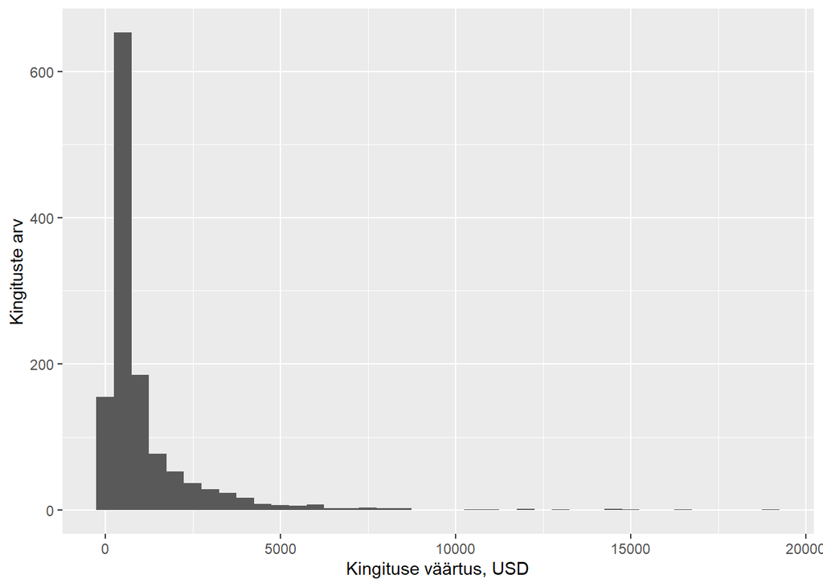

```r
gifts %>%
  filter(region == "Europe" & value_usd < 25000) %>%
  ggplot(aes(x = value_usd)) +
  geom_histogram(binwidth = 500) +
  scale_x_continuous("Kingituse väärtus, USD") +
  scale_y_continuous("Kingituste arv")
```

### Järskuskordaja

Järskuskordaja väärtus arvutatakse nii, et mida lamedam on tunnuse jaotus (erinevad väärtused tunnuse skaalal on sarnasemate sagedustega, jaotuse n-ö sabad on tüsedamad), seda suurema negatiivse väärtusega on järskuskordaja. Mida teravatipulisem on tunnuse jaotus (jaotusel on terav tipp, jaotuse sabad on üsna õhukesed ja keskmisest kaugeleulatuvad), seda suurema positiivse väärtusega on järskuskordaja. Järskuskordaja väärtus on 0, kui jaotuse järskus langeb kokku normaaljaotusega, mis on üks enimkasutatavaid tüüpjaotusi.

Arvutame järskuskordajad regiooniti funktsiooniga `kurtosi` paketist `psych`.

```r
gifts %>%
  group_by(region) %>%
  summarise(keskmine = mean(value_usd, na.rm = TRUE),
            disp = var(value_usd, na.rm = TRUE),
            std = sd(value_usd, na.rm = TRUE),
            aad = aad(value_usd, na.rm = TRUE),
            alum_kvart = quantile(value_usd, probs = 0.25, na.rm = TRUE),
            mediaan = median(value_usd, na.rm = TRUE),
            ylem_kvart = quantile(value_usd, probs = 0.75, na.rm = TRUE),
            iqr = IQR(value_usd, na.rm = TRUE),
            mad = mad(value_usd, constant = 1, na.rm = TRUE),
            mood = mfv(value_usd, na_rm = TRUE), # miskipärast on funktsiooni mfv loojad otsustanud nimetada teise argumendi `na_rm`, mitte `na.rm`
            min = min(value_usd, na.rm = TRUE),
            max = max(value_usd, na.rm = TRUE),
            asymm = skew(value_usd),
            jarskus = kurtosi(value_usd),
            arv = n()) %>%
  arrange(desc(keskmine)) %>%
  print(width = Inf)
```

```
## # A tibble: 6 × 16
##   region   keskmine       disp    std   aad alum_kvart mediaan ylem_kvart   iqr
##   <chr>       <dbl>      <dbl>  <dbl> <dbl>      <dbl>   <dbl>      <dbl> <dbl>
## 1 Asia        3580. 810496494. 28469. 4815.       410.    650       1500  1090.
## 2 Africa      1963.  95563696.  9776. 2184.       416.    630       1204.  788.
## 3 <NA>        1490.   4014910.  2004. 1179.       500     774.      1668  1168
## 4 Europe      1294.  16767489.  4095. 1207.       385     550       1150   765
## 5 Oceania     1141.   4220944.  2054. 1061.       310.    513.      1000   690.
## 6 Americas     864.   3976021.  1994.  625.       385.    500        850   465.
##     mad  mood   min      max asymm jarskus   arv
##   <dbl> <dbl> <dbl>    <dbl> <dbl>   <dbl> <int>
## 1  304.   500  1.32 1000000  23.0    628.   4233
## 2  280    450 30     212225  17.1    340.    715
## 3  391.   500  6      23760.  4.35    28.2  1417
## 4  250    500  1     124000  22.4    635.   1361
## 5  350.  1000 15      17031   4.95    31.0   125
## 6  183.   500  3.54   40000  15.6    293.    541
```

Vahemärkus: kõigi eelnevate näidete puhul on enamiku jaotusparameetrite funktsioonide puhul eraldi defineeritud argument `na.rm = TRUE`, mis eemaldab tunnusest `value_usd` andmelüngad, muidu saaksime jaotusparameetrite väärtusteks `NA` (sest andmelünk ehk puuduv väärtus tunnuses ei võimalda jaotusparameetrit arvutada). Saab ka lihtsamini, funktsiooniga `drop_na`; see funktsioon eemaldab analüüsist andmeread, mille puhul on vaadeldavas tunnuses (st tunnusel, mis on lisatud funktsiooni argumendiks) andmelünk.

```r
gifts %>%
  group_by(region) %>%
  drop_na(value_usd) %>%
  summarise(keskmine = mean(value_usd),
            disp = var(value_usd),
            std = sd(value_usd),
            aad = aad(value_usd),
            alum_kvart = quantile(value_usd, probs = 0.25),
            mediaan = median(value_usd),
            ylem_kvart = quantile(value_usd, probs = 0.75),
            iqr = IQR(value_usd),
            mad = mad(value_usd, constant = 1),
            mood = mfv(value_usd),
            min = min(value_usd),
            max = max(value_usd),
            asymm = skew(value_usd),
            jarskus = kurtosi(value_usd),
            arv = n()) %>%
  arrange(desc(keskmine)) %>%
  print(width = Inf)
```

[output not shown]

Järskuskordajad on väga kõrged nagu näitas ka eelnev joonis Euroopa puhul.

Kui asümmeetria- ja järskuskordaja väärtused on 0, langeb tunnuse jaotus kokku normaaljaotusega. Miks see on oluline? Normaaljaotus on üks enamlevinud tüüpjaotusi, mis on paljude statistiliste meetodite kasutamise eelduseks. Meetodi eeldus tähendab siinjuures seda, et kui soovime mingeid tunnuseid mingi meetodi abil analüüsida, peavad tunnused vastama teatud nõudmistele, nt tunnuse jaotus peab olema lähedane mingile etteantud jaotusele. Tihti ongi selliseks etalonjaotuseks normaaljaotus. Näiteks selleks, et aritmeetiline keskmine kirjeldaks adekvaatselt tunnuse tüüpilisi väärtusi, oleks hea, et tunnuse jaotus oleks lähedane normaaljaotusele (kindlasti peaks olema vähemalt sümmeetrilise või sellele lähedase jaotusega).

Mida normaaljaotus endast kujutab? Standardiseeritud normaaljaotuse puhul on tegu jaotusega, mille keskmine on 0 ja dispersioon 1. Jaotus on kellukakujuline, vahel nimetatakse seda ka Gaussi jaotuseks:

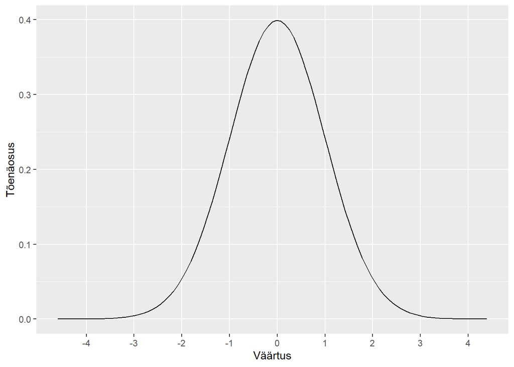

Normaaljaotusega tunnuse jaotuse puhul kehtib reegel (tasub järgmiseks korraks meelde jätta), et - 90% tunnuse väärtustest on aritmeetilisest keskmisest kuni 1,645 standardhälbe kaugusel (st mõlemale poole tunnuse keskmisest), - 95% tunnuse väärtustest on aritmeetilisest keskmisest kuni 1,96 standardhälbe kaugusel ja - 99% tunnuse väärtustest on aritmeetilisest keskmisest kuni 2,575 standardhälbe kaugusel.

## Jaotusparameetrid kokkuvõtlikult

Eelnevalt arvutasime jaotusparameetrid eraldi funktsioonide abil, grupiti saime need jaotusparameetrid arvutada `dplyr`’i abil. See võimaldab tellida just need jaotusparameetrid, mida parajasti vaja on. Ka annab funktsioon `summarise` väljundi *data frame*’i kujul, mida on mugav vajadusel edasi analüüsida (nt kasutada jooniste tegemiseks). Jaotusparameetrid on siiski võimalik tellida ka korraga. Seda saab teha nt funktsiooniga `descr` paketist `summarytools`.

```r
descr(gifts$value_usd)
```

```
## Descriptive Statistics
## gifts$value_usd
## N: 8392
##
##                      value_usd
## ----------------- ------------
##              Mean      2520.67
##           Std.Dev     20654.44
##               Min         1.00
##                Q1       410.00
##            Median       645.50
##                Q3      1450.25
##               Max   1000000.00
##               MAD       443.15
##               IQR      1040.12
##                CV         8.19
##          Skewness        31.12
##       SE.Skewness         0.03
##          Kurtosis      1169.12
##           N.Valid      8116.00
##         Pct.Valid        96.71
```

Mitme grupi kohta jaotusparameetrite saamiseks tuleb kasutada funktsiooni `stby` koos funktsiooniga `with`: funktsiooni `with` esimese argumendiga paneme paika andmestiku, teise argumenti läheb funktsioon `stby`, millest täpsustame tunnuse, mille alusel midagi arvutada tahame, kategoriseeriva tunnuse ja funktsiooni, mille abil arvutused teeme.

```r
with(gifts, stby(value_usd, region, descr))
```

```
## Descriptive Statistics
## value_usd by region
## Data Frame: gifts
## N: 715
##
##                        Africa   Americas         Asia      Europe    Oceania
## ----------------- ----------- ---------- ------------ ----------- ----------
##              Mean     1963.13     863.90      3580.26     1293.69    1140.72
##           Std.Dev     9775.67    1994.00     28469.22     4094.81    2054.49
##               Min       30.00       3.54         1.32        1.00      15.00
##                Q1      415.00     384.79       410.00      385.00     309.00
##            Median      630.00     500.00       650.00      550.00     513.14
##                Q3     1205.00     850.00      1500.00     1150.00    1000.00
##               Max   212225.00   40000.00   1000000.00   124000.00   17031.00
##               MAD      415.13     270.87       451.45      370.65     519.45
##               IQR      787.50     464.79      1089.75      765.00     690.50
##                CV        4.98       2.31         7.95        3.17       1.80
##          Skewness       17.15      15.61        23.02       22.40       4.95
##       SE.Skewness        0.10       0.11         0.04        0.07       0.22
##          Kurtosis      340.36     293.21       628.41      635.47      30.96
##           N.Valid      658.00     507.00      4146.00     1289.00     120.00
##         Pct.Valid       92.03      93.72        97.94       94.71      96.00
```

Jaotusparameetrite tabeli saab ka nt funktsiooniga `describe` paketist `psych`. Kui soovime ka kvantiile, tuleb need käsus täpsustada.

```r
describe(gifts$value_usd, quant = c(.25, .75))
```

```
##   vars    n    mean       sd median trimmed    mad min   max  range  skew
## 1    1 8116 2520.67 20654.44  645.5  919.99 443.15   1 1e+06 999999 31.12
##   kurtosis     se Q0.25   Q0.75
## 1  1169.12 229.27   410 1450.12
```

Grupiti saab paketis `psych` jaotusparameetrid tellida funktsiooniga describeBy:

```r
describeBy(value_usd ~ region, data = gifts, quant = c(.25, .75))
```

```
##
##  Descriptive statistics by group
## region: Africa
##   vars   n    mean      sd median trimmed    mad min    max  range  skew
## 1    1 658 1963.13 9775.67    630     840 415.13  30 212225 212195 17.15
##   kurtosis    se  Q0.25   Q0.75
## 1   340.36 381.1 416.25 1203.75
## ------------------------------------------------------------
## region: Americas
##   vars   n  mean   sd median trimmed    mad  min   max    range  skew kurtosis
## 1    1 507 863.9 1994    500  618.66 270.87 3.54 40000 39996.46 15.61   293.21
##      se  Q0.25 Q0.75
## 1 88.56 385.21   850
## ------------------------------------------------------------
## region: Asia
##   vars    n    mean       sd median trimmed    mad  min   max    range  skew
## 1    1 4146 3580.26 28469.22    650 1004.28 451.45 1.32 1e+06 999998.7 23.02
##   kurtosis     se  Q0.25 Q0.75
## 1   628.41 442.14 410.25  1500
## ------------------------------------------------------------
## region: Europe
##   vars    n    mean      sd median trimmed    mad min    max  range skew
## 1    1 1289 1293.69 4094.81    550   781.2 370.65   1 124000 123999 22.4
##   kurtosis     se Q0.25 Q0.75
## 1   635.47 114.05   385  1150
## ------------------------------------------------------------
## region: Oceania
##   vars   n    mean      sd median trimmed    mad min   max range skew kurtosis
## 1    1 120 1140.72 2054.49 513.14  695.16 519.45  15 17031 17016 4.95    30.96
##       se Q0.25 Q0.75
## 1 187.55 309.5  1000
```

## Ülesanne 1

Osa kingitusi on tehtud USA presidendi (õieti küll presidentide, sest vaadeldavas ajavahemikus on USA-l olnud mitu presidenti) lastele (“First Family Children” tunnuses `recipient`). Kui palju neile kingitusi on tehtud, milliste riikide esindajad on neile kingitusi toonud? Tehke alustuseks nende riikide jaotus. Enne, kui vaatate, kui suures rahalises vääringus kingitusi presidendi lastele on tehtud, püüdke jaotusparameetrite põhjal hinnata, millises suurusjärgus on neile tehtud kingituste tüüpilised rahalised väärtused, missuguse kujuga võib olla jaotuse kuju, kas võib esineda teistest tugevalt eristuvaid väärtuseid (eriti kalleid või odavaid kingitusi). Milline on lastele tehtud kingituste rahaliste väärtuste hajuvus võrreldes nt esileedile tehtud kingitustega (võtke siin lihtsuse mõttes aluseks väärtus “First Lady” tunnuses `recipient`) - mida järeldaksite selle osas ainult miinimumi ja maksimumi põhjal, mida ka teisi jaotusparameetreid arvesse võttes? Kui vaatate andmestikus otsa lastele tehtud kingituste rahalistele väärtustele, kas need kinnitavad jaotusparameetrite põhjal tehtud järeldusi?

Pärast eelnevatele küsimustele vastamist vaadake ka huvi pärast, millise riigi esindajad on teinud lastele kõige kallemaid kingitusi, millist tüüpi kingitusi on presidendi lastele kõige rohkem tehtud, milline on kõige eriskummalisem kingitus.

Proovige ülesanne teha läbi kõigepealt iseseisvalt eelnevate näidete koodi põhjal. Kui jääte jänni, siis…

**väljundi nägemiseks klikkige siia**

```
##                 Freq    % Valid % Valid Cum.    % Total % Total Cum.
## Total             26 100.000000   100.000000 100.000000   100.000000
## Brazil             3  13.043478    21.739130  11.538462    19.230769
## Saudi Arabia       3  13.043478    91.304348  11.538462    80.769231
## <NA>               3         NA           NA  11.538462   100.000000
## Australia          2   8.695652     8.695652   7.692308     7.692308
## France             2   8.695652    43.478261   7.692308    38.461538
## Russia             2   8.695652    78.260870   7.692308    69.230769
## Canada             1   4.347826    26.086957   3.846154    23.076923
## Chile              1   4.347826    30.434783   3.846154    26.923077
## China              1   4.347826    34.782609   3.846154    30.769231
## Germany            1   4.347826    47.826087   3.846154    42.307692
## India              1   4.347826    52.173913   3.846154    46.153846
## Indonesia          1   4.347826    56.521739   3.846154    50.000000
## Ireland            1   4.347826    60.869565   3.846154    53.846154
## Myanmar (Burma)    1   4.347826    65.217391   3.846154    57.692308
## New Zealand        1   4.347826    69.565217   3.846154    61.538462
## Spain              1   4.347826    95.652174   3.846154    84.615385
## Turkey             1   4.347826   100.000000   3.846154    88.461538
```

```
## # A tibble: 2 × 16
##   recipient             keskmine       disp    std   aad alum_kvart mediaan
##   <chr>                    <dbl>      <dbl>  <dbl> <dbl>      <dbl>   <dbl>
## 1 First Family Children    4099. 240845927. 15519. 5865.       502.    684.
## 2 First Lady               1503.  47360994.  6882. 1752.       290.    450
##   ylem_kvart   iqr   mad  mood   min   max asymm jarskus   arv
##        <dbl> <dbl> <dbl> <dbl> <dbl> <dbl> <dbl>   <dbl> <int>
## 1       864.  361.  189.   470  361. 80000  4.49    19.0    26
## 2       944.  654.  252    350    5  95500 12.0    153.    362
```

```
## # A tibble: 26 × 3
##    donor_country   value_usd gift_description
##    <chr>               <dbl> <chr>
##  1 Saudi Arabia       80000  "Diamond and emerald jewelry set including earring…
##  2 Myanmar (Burma)     4440  "Two flower brooches of pearl, gold, and diamond. …
##  3 Saudi Arabia        3775  "Jewelry set including heart-shaped diamond earrin…
##  4 Saudi Arabia        3500  "Jewelry set including square diamond earrings and…
##  5 India               1495  "Two books on tigers by Valmik Thapar. 46'' x 33''…
##  6 France              1419  "Hermes PM Skipper bracelet, light blue silk cord …
##  7 Turkey               880  "Two beige shawls with pearl and lace detail. Two …
##  8 Chile                815  "Four dresses and two jackets, designed by Isabel …
##  9 New Zealand          801. "Four clothing sets of knit gloves, felted hat, an…
## 10 <NA>                 740  "Two purple Samsung compact digital cameras; two p…
## 11 Russia               720  "4'' x 3'' Black Russian ``MOCKBA KPEMJIb'' keepsa…
## 12 Canada               718  "Two 18'' x 12'' Roots brown leather backpacks pri…
## 13 Brazil               686. "Personalized red and green Adidas soccer jersey w…
## 14 Brazil               683. "Personalized red, white, and green striped Adidas…
## 15 <NA>                 660  "Two Trisha-brand silver necklaces with circle and…
## 16 <NA>                 570  "Four pink and orange scarves; one teddy bear; and…
## 17 Germany              557  "Adidas Blue Storm Kids' swimming goggles. Adidas …
## 18 Ireland              554. "Book, title: ``At the Gateways of the Day (1924):…
## 19 Spain                510  "Two 8'' gold Pina & Grau bracelets with 0.5'' Mal…
## 20 Russia               500  "Two 15-piece nesting dolls. Rec'd--7/07/ 2009. Es…
## 21 China                490  "Box, cloisonn[eacute], round, lidded, displaying …
## 22 Australia            470  "Four books and seventeen DVDs. Rec'd-- 4/02/2009.…
## 23 Brazil               470  "Two 6\" x 4.5\" x 2\" wooden jewelry box with lil…
## 24 Australia            388  "Toy brown kangaroo stuffed animal with a baby kan…
## 25 Indonesia            380  "Four pairs of Nike shoes with Batik design. Set o…
## 26 France               361. "Pink outfit from Bonpoint Paris clothing store. G…
```

**koodi nägemiseks klikkige siia**

```r
gifts %>%
  filter(recipient == "First Family Children") %>%
  freq(donor_country) %>%
  as.data.frame() %>%
  arrange(desc(Freq))

gifts %>%
  filter(recipient %in% c("First Family Children", "First Lady")) %>%
  drop_na(value_usd) %>%
  group_by(recipient) %>%
  summarise(keskmine = mean(value_usd, na.rm = TRUE),
            disp = var(value_usd, na.rm = TRUE),
            std = sd(value_usd, na.rm = TRUE),
            aad = aad(value_usd, na.rm = TRUE),
            alum_kvart = quantile(value_usd, probs = 0.25, na.rm = TRUE),
            mediaan = median(value_usd, na.rm = TRUE),
            ylem_kvart = quantile(value_usd, probs = 0.75, na.rm = TRUE),
            iqr = IQR(value_usd, na.rm = TRUE),
            mad = mad(value_usd, constant = 1, na.rm = TRUE),
            mood = mlv(value_usd, method = "mfv", na_rm = TRUE),
            min = min(value_usd, na.rm = TRUE),
            max = max(value_usd, na.rm = TRUE),
            asymm = skew(value_usd),
            jarskus = kurtosi(value_usd),
            arv = n()) %>%
  arrange(desc(keskmine))

gifts %>%
  filter(recipient == "First Family Children") %>%
  select(donor_country, value_usd, gift_description) %>%
  arrange(desc(value_usd)) %>%
  View()
```

## Jaotusparameetrid kaalutud andmetega

Kui analüüsime küsitlusandmeid, on enamasti tarvis andmeid ka kaaluda. Jaotusparameetrid saab arvutada ka kaalutud andmetega, R-s on enamiku jaoks neist funktsioonid olemas. Enamik jaotusparameetrite funktsioonidest, mis võimaldavad kaale arvesse võtta, pärinevad siinkohal paketist `TAM`, välja arvatud `weightedMad`, mis pärineb paketist `matrixStats`.

Arvutame näitena tunnuse `grspnum` ehk tavalise kuu brutosissetuleku kaalutud jaotusparameetrid.

```r
r9 <- read_spss("data/ESS9e03_1.sav")
ee9 <- r9 %>%
  filter(cntry == "EE")

ee9 %>%
  drop_na(grspnum) %>%
  group_by(region) %>%
  summarise(keskmine = weighted_mean(grspnum, w = pspwght),
            disp = weighted_var(grspnum, w = pspwght),
            std = weighted_sd(grspnum, w = pspwght),
            alum_kvart = weighted_quantile(grspnum, w = pspwght, probs = 0.25),
            mediaan = weighted_quantile(grspnum, w = pspwght, probs = 0.5),
            ylem_kvart = weighted_quantile(grspnum, w = pspwght, probs = 0.75),
            iqr = ylem_kvart - alum_kvart,
            mad = weightedMad(grspnum, constant = 1),
            min = min(grspnum),
            max = max(grspnum),
            asymm = weighted_skewness(grspnum, w = pspwght),
            jarskus = weighted_kurtosis(grspnum, w = pspwght),
            arv = sum(pspwght)) %>%
  print(width = Inf)
```

```
## # A tibble: 5 × 14
##   region              keskmine    disp   std alum_kvart mediaan ylem_kvart   iqr
##   <chr+lbl>              <dbl>   <dbl> <dbl>      <dbl>   <dbl>      <dbl> <dbl>
## 1 EE001 [Põhja-Eesti]    1345. 646965.  804.       798.    1200      1800  1002.
## 2 EE004 [Lääne-Eesti]    1130. 744899.  863.       624.    1000      1370.  746.
## 3 EE006 [Kesk-Eesti]     1132. 644947.  803.       618.    1000      1328.  709.
## 4 EE007 [Kirde-Eesti]     865. 287570.  536.       500      650      1200   700
## 5 EE008 [Lõuna-Eesti]    1191. 638736.  799.       650     1000      1500   850
##     mad min       max       asymm jarskus   arv
##   <dbl> <dbl+lbl> <dbl+lbl> <dbl>   <dbl> <dbl>
## 1   475 0         4500      0.883   1.17  397.
## 2   378 0         5000      2.05    6.51  111.
## 3   370 0         3900      1.56    2.67   87.3
## 4   175 0         2500      1.14    0.686  61.0
## 5   400 0         4600      1.52    3.70  223.
```

Olen paketti `summarytools` kasutanud paljuski seepärast, et see võimaldab saada ülevaatliku jaotusparameetrite tabeli mitte ainult kaalumata, vaid ka kaalutud andmetele (mitte küll kõiki jaotusparameetreid, aga osad siiski).

```r
descr(ee9$grspnum, weights = ee9$pspwght)
```

```
## Weighted Descriptive Statistics
## ee9$grspnum
## Label: What is your usual [weekly/monthly/annual] gross pay
## Weights: pspwght
## N: 1904
##
##                   grspnum
## --------------- ---------
##            Mean   1224.17
##         Std.Dev    804.36
##             Min      0.00
##          Median   1100.00
##             Max   5000.00
##             MAD    667.17
##              CV      0.66
##         N.Valid    879.09
##       Pct.Valid     46.17
```

Panin aga just tähele, et kui `descr` saab hästi hakkama kaalumata andmetega ja ka *kogu* tunnuse jaotusparameetrite arvutamisega kaalutud andmetega, siis kaalutud andmete pealt teise tunnuse kategooriate lõikes (nt regiooniti) arvutab `descr` jaotusparameetrid küll ära, aga tulemused on mõnevõrra erinevad võrreldes teiste sarnaste funktsioonidega. Ei oska öelda, miks täpselt see nii on, igatahes kaalutud andmete põhjal *grupiti* jaotusparameetrite arvutamiseks soovitaksin `descr`’i asemel eelkõige eelnevat `dplyr`’i varianti, kus kõik jaotusparameetrid arvutatakse eraldi funktsioonidega.

## Ülesanne 2

ESS-s küsitakse, kuivõrd vastaja usaldab seitset erinevat institutsiooni. Neist viis küsimust (tunnused `trstprl` kuni `trstprt`) on siseriiklike institutsioonide usaldamise kohta. Koostage nende alusel n-ö indekstunnus, mille väärtuseks saab igal indiviidil tema poolt siseriiklikele institutsioonidele antud usaldushinnangute keskmine (vihje: abi on funktsioonist `mutate`). Arvutage saadud tunnuse jaotusparameetreid (andmeid kaaludes!) nende kohta, kes tajuvad, et neid mingil põhjusel diskrimineeritakse, ja nende kohta, kes diskrimineerimist enda suhtes ei taju (tunnus `dscrgrp`). Kas/kuivõrd nendes kahes grupis keskmine institutsioonide usaldamise tase erineb, kuivõrd varieerub erinevalt?

Nagu eelmise ülesande puhul, proovige ülesanne teha kõigepealt iseseisvalt eelneva koodi põhjal. Kui vajate abi, siis…

**väljundi nägemiseks klikkige siia**

```
## # A tibble: 2 × 14
##   dscrgrp   keskmine  disp   std alum_kvart mediaan ylem_kvart   iqr   mad   min
##   <dbl+lbl>    <dbl> <dbl> <dbl>      <dbl>   <dbl>      <dbl> <dbl> <dbl> <dbl>
## 1 1 [Yes]       4.42  4.11  2.03          3     4.6        6     3     1.4     0
## 2 2 [No]        5.18  3.43  1.85          4     5.4        6.6   2.6   1.2     0
##     max  asymm jarskus   arv
##   <dbl>  <dbl>   <dbl> <dbl>
## 1   8.2 -0.386  -0.591  149.
## 2  10   -0.346  -0.195 1708.
```

**koodi nägemiseks klikkige siia**

```r
ee9 <- ee9 %>%
  mutate(trust = (trstprl + trstlgl + trstplc + trstplt + trstprt) / 5)

ee9 %>%
  drop_na(trust, dscrgrp) %>%
  group_by(dscrgrp) %>%
  summarise(keskmine = weighted_mean(trust, w = pspwght),
            disp = weighted_var(trust, w = pspwght),
            std = weighted_sd(trust, w = pspwght),
            alum_kvart = weighted_quantile(trust, w = pspwght, probs = 0.25),
            mediaan = weighted_quantile(trust, w = pspwght, probs = 0.5),
            ylem_kvart = weighted_quantile(trust, w = pspwght, probs = 0.75),
            iqr = ylem_kvart - alum_kvart,
            mad = weightedMad(trust, constant = 1),
            min = min(trust),
            max = max(trust),
            asymm = weighted_skewness(trust, w = pspwght),
            jarskus = weighted_kurtosis(trust, w = pspwght),
            arv = sum(pspwght)) %>%
  print(width = Inf)
```